# R Notebook

# Summary

## Step 0: Related Papers and Projects

#### We read more than 4 papers including Post-Earnings Announcement Effect, Momentum and Trend Following in Global Asset Allocation, and etc. Details and links of papers can be found in data/paper/ListofStrategyPapers.xlsx. We then implemented methods and algorithms described in those papers.

## Step 1: Data Collection And Processing Using Matlab

#### • Data source: Using Bloomberg terminal to get stock related data(including EBIT_growth,Price to book value and 7 other indicators) and 06-17 earning announcement data. Original data can be found in data/original.

#### • Size: 9 files with a total size of 150MB

#### • Data Processing: For each announcement, we need to find the correspoding entry with same sticker and date in 9 indicators files respectively. We also calculate 1-year-Momentum = (Closing Price of Date a / Closing Price of Data(a-252) * 100 ). All the processing process took place in Matlab. Codes can be found at lib/data_process_matlab

#### • Result: We got 10 processed CSV files and you can find them at data/observation

## Step 2: Select the stocks based on their Momentum

#### • Data Processing: Using R to select 1500 observations with highest Momentum and use Python to reorganize data and store them in a proper way. ()

#### • Result:

```r
setwd("~/Spr2017-proj5-grp15/data/original/")
```

```
The working directory was changed to /Users/yuxin/Spr2017-proj5-grp15/data/original inside a notebook chunk. The working directory will be reset when the chunk is finished running. Use the knitr root.dir option in the setup chunk to change the the working directory for notebook chunks.
```

```r
mom <- read.csv("../observation/momentum39034.csv",header = FALSE)
n_rows=nrow(mom)
## Long_before_earning.csv and Short_after_earning.csv are written using Python
long_before <- read.csv('../observation_processed/long_before_earning.csv')
short_after <- read.csv('../observation_processed/short_after_earning.csv')
nrow_longb=nrow(long_before)
nrow_shorta=nrow(short_after)
mom_sa=c()
for (i in 1:nrow_shorta){
  inter=max(short_after[i,'MOMENTUM'])
  mom_sa=c(mom_sa,inter)
}
mom_sa_selected=sort(mom_sa,decreasing=TRUE,index.return=TRUE)
sa_selected=mom_sa_selected$ix[1:1500]
sa_data_selected=short_after[sa_selected,]
mom_lb=c()
for (i in 1:nrow_longb){
  inter=max(long_before[i,'MOMENTUM'])
  mom_lb=c(mom_lb,inter)
}
mom_lb_selected=sort(mom_lb,decreasing=TRUE,index.return=TRUE)
lb_selected=mom_lb_selected$ix[1:1500]
lb_data_selected=long_before[lb_selected,]
```

```r
packages.used=c("gbm", "caret","DMwR" ,"nnet","randomForest","e1071")
# check packages that need to be installed.
packages.needed=setdiff(packages.used,
                        intersect(installed.packages()[,1],
                                  packages.used))
# install additional packages
if(length(packages.needed)>0){
  install.packages(packages.needed, dependencies = TRUE)
}
```

# Load and Process Data

```r
setwd("~/Spr2017-proj5-grp15/data/observation/")
```

```
The working directory was changed to /Users/yuxin/Spr2017-proj5-grp15/data/observation inside a notebook chunk. The working directory will be reset when the chunk is finished running. Use the knitr root.dir option in the setup chunk to change the the working directory for notebook chunks.
```

```r
short_after_selected <- read.csv("short_after20.csv")
long_after_selected <- read.csv("long_before20.csv")
colnames(long_after_selected)[1] <- "y"
long_after_selected$y <- ifelse(long_after_selected$RETURN >0, 1, 0)
long_after_selected <- long_after_selected[,c(-2,-12)]
colnames(short_after_selected)[1] <- "y"
short_after_selected$y <- ifelse(short_after_selected$RETURN >0, 1,0)
short_after_selected <- short_after_selected[,c(-2,-12)]
test.index <- sample(1:1500,300,replace = F)
test.sas <- short_after_selected[test.index,]
test.lbs <- long_after_selected[test.index,]
test.sas.x <- test.sas[,-1]
test.lbs.x <- test.lbs[,-1]
train.sas <- short_after_selected[-test.index,]
train.lbs <- long_after_selected[-test.index,]
```

```r
source("../lib/evaluation_measures.R")
source("../lib/train.R")
source("../lib/test.R")
source("../lib/cross_validation.R")
```

# Short After Model

### GBM

```r
# GBM
start.time <- Sys.time()
res_gbm = train.gbm(train.sas)
pred.gbm = test.gbm(res_gbm,test.sas.x)
sas.gbm.sum = table(pred.gbm,test.sas$y)
end.time <- Sys.time()
gbm.sas.time <- end.time-start.time
perf_sas_gbm <- performance_statistics(sas.gbm.sum)
perf_sas_gbm
```

```
$precision
[1] 0.7479675

$recall
[1] 0.9019608

$f1
[1] 0.8177778

$accuracy
[1] 0.7266667
```

### SVM

```r
# model.svm <- svm(y ~ ., data = train.sas, cost = 256, gamma = 0.3)
# Tune svm
start.time <- Sys.time()
model.svm.sas <- train.svm(train.sas)
pre.svm <- test.svm(model.svm.sas,test.sas.x)
svm.sas <- table(pre.svm,test.sas$y)
end.time <- Sys.time()
svm.sas.time <- end.time-start.time
perf_sas_svm <- performance_statistics(svm.sas)
perf_sas_svm
```

```
$precision
[1] 0.7608696

$recall
[1] 0.8578431

$f1
[1] 0.8064516

$accuracy
[1] 0.72
```

### BPNN

```r
# netural network
start.time <- Sys.time()
# model.nnet <- nnet(y ~ ., data = train.sas, linout = F, size = 10, decay = 0.001, maxit = 200, trace = F, MaxNWts=6000)
# Tune bpnn
model.nnet <- train.bp(train.sas)
pre.nnet <- test.bp(model.nnet,test.sas.x)
nnet.sas <- table(pre.nnet,test.sas$y)
end.time <- Sys.time()
nnet.sas.time <- end.time-start.time
perf_sas_nnet <- performance_statistics(nnet.sas)
perf_sas_nnet
```

```
$precision
[1] 0.7418033

$recall
[1] 0.8872549

$f1
[1] 0.8080357

$accuracy
[1] 0.7133333
```

### Random Forest

```
mtry = 3  OOB error = 15.5%
Searching left ...
mtry = 2    OOB error = 15.5%
0 1e-05
Searching right ...
mtry = 4    OOB error = 15.67%
-0.01075269 1e-05
```

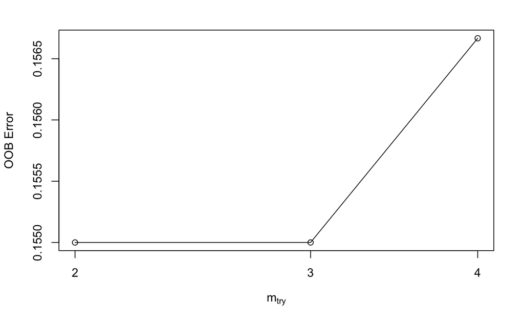

```r
# Random Forest
start.time <- Sys.time()
model.rf <- train.rf(train.sas)
```

```r
pre.rf <- test.rf(model.rf,test.sas.x)
rf.sas <- table(pre.rf,test.sas$y)
end.time <- Sys.time()
rf.sas.time <- end.time-start.time
perf_sas_rf <- performance_statistics(rf.sas)
perf_sas_rf
```

```
$precision
[1] 0.8883495

$recall
[1] 0.8970588

$f1
[1] 0.8926829

$accuracy
[1] 0.8533333
```

### Logistic

```r
start.time <- Sys.time()
res_logi = train.log(train.sas)
pred.logi = test.log(res_logi,test.sas.x)
log.sas <- table(pred.logi,test.sas$y)
end.time <- Sys.time()
log.sas.time <- end.time-start.time
perf_sas_log <- performance_statistics(log.sas)
perf_sas_log
```

```
$precision
[1] 0.6789298

$recall
[1] 0.995098

$f1
[1] 0.8071571

$accuracy
[1] 0.6766667
```

### Majority Vote(Equal Weight)

```r
# Majority Vote
pre=(as.numeric(as.character(pre.svm))+as.numeric(as.character(pred.gbm))+as.numeric(as.character(pre.rf)))
pre=ifelse(pre>=2,1,0)
mv <- table(pre,test.sas$y)
perf_sas_mv <- performance_statistics(mv)
perf_sas_mv
```

```
$precision
[1] 0.8095238

$recall
[1] 0.9166667

$f1
[1] 0.8597701

$accuracy
[1] 0.7966667
```